# MTHM_505

```r
model_arima1 <- Arima(ts_data, order = c(2,1,1), include.drift = TRUE)
model_arima1
```

```
## Series: ts_data
## ARIMA(2,1,1) with drift
##
## Coefficients:
##          ar1     ar2     ma1   drift
##       0.5400  0.2084  -1.000  0.0018
## s.e.  0.0486  0.0490   0.008  0.0002
##
## sigma^2 = 0.0119:  log likelihood = 324.24
## AIC=-638.49   AICc=-638.34   BIC=-618.44
```

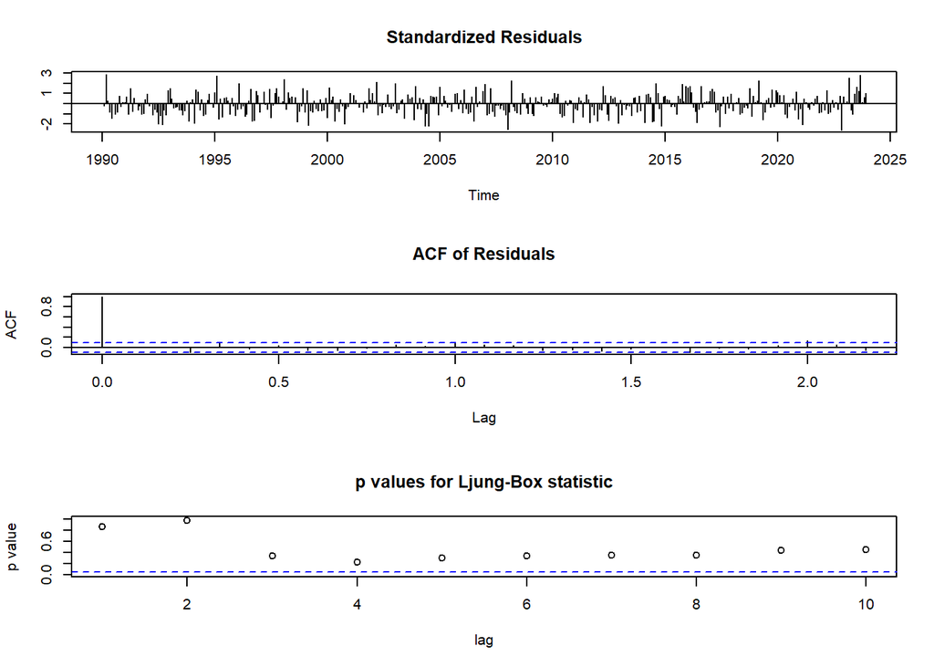

```r
tsdiag(model_arima1)
```

```r
model_arima2 <- Arima(ts_data, order = c(1,1,2), include.drift = TRUE)
model_arima2
```

```
## Series: ts_data
## ARIMA(1,1,2) with drift
##
## Coefficients:
##          ar1      ma1     ma2   drift
##       0.8211  -1.2643  0.2643  0.0018
## s.e.  0.0413   0.0657  0.0653  0.0002
##
## sigma^2 = 0.01198:  log likelihood = 323.01
## AIC=-636.02   AICc=-635.87   BIC=-615.98
```

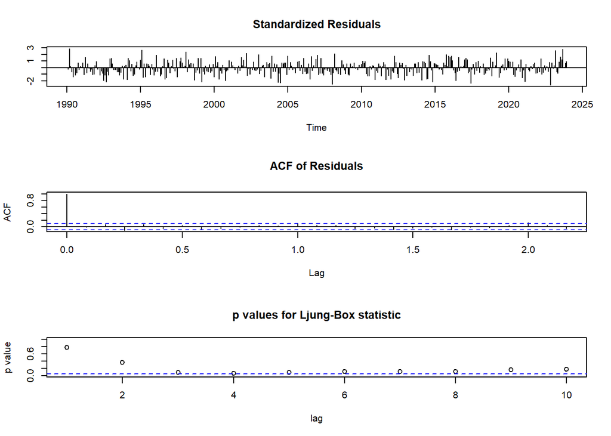

```r
tsdiag(model_arima2)
```

```r
model_arima4 <- Arima(ts_data, order = c(2,1,2), include.drift = TRUE)
model_arima4
```

```
## Series: ts_data
## ARIMA(2,1,2) with drift
##
## Coefficients:
##          ar1     ar2      ma1      ma2   drift
##       0.0016  0.5635  -0.4213  -0.5787  0.0018
## s.e.  0.1418  0.0887   0.1605   0.1603  0.0002
##
## sigma^2 = 0.01179:  log likelihood = 326.51
## AIC=-641.02   AICc=-640.81   BIC=-616.97
```

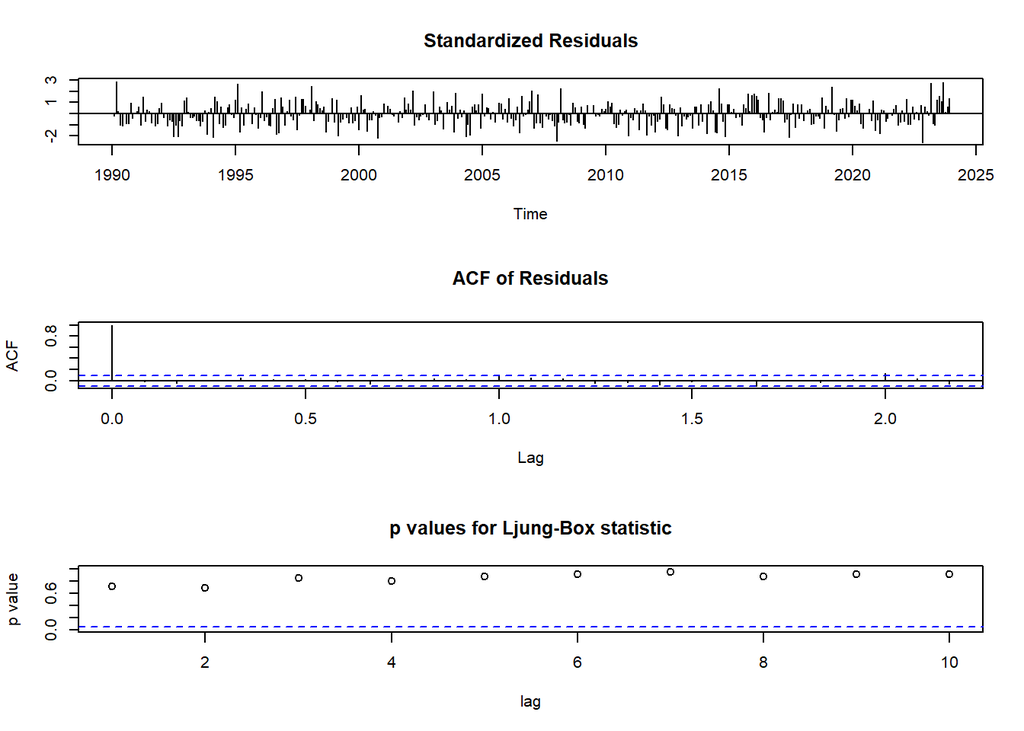

```r
tsdiag(model_arima4)
```

- ARIMA model can take difference value term so I have taken d=1 for the all the ARIMA model fits.

#2c)

```r
# aggregating teh data from monthly to quarterly data by the average method
ts_data_quarterly <- aggregate(ts_data, nfrequency = 4, FUN = mean)
ts_data_quarterly
```

```
##            Qtr1       Qtr2       Qtr3       Qtr4
## 1990 0.51933333 0.53833333 0.37400000 0.41700000
## 1991 0.45133333 0.53466667 0.47166667 0.34333333
## 1992 0.47166667 0.32533333 0.06900000 0.09933333
## 1993 0.40666667 0.34666667 0.22866667 0.21066667
## 1994 0.26066667 0.41966667 0.29133333 0.41700000
## 1995 0.59466667 0.49333333 0.49500000 0.43400000
## 1996 0.45700000 0.35733333 0.39533333 0.36533333
## 1997 0.45166667 0.52366667 0.47800000 0.68300000
## 1998 0.74166667 0.79166667 0.66300000 0.53800000
## 1999 0.52766667 0.40400000 0.41166667 0.41933333
## 2000 0.49866667 0.50533333 0.44666667 0.31833333
## 2001 0.54066667 0.59700000 0.54066667 0.62666667
## 2002 0.81433333 0.65500000 0.62000000 0.58633333
## 2003 0.67100000 0.60300000 0.64133333 0.68833333
```

[output cut: 20 more lines]

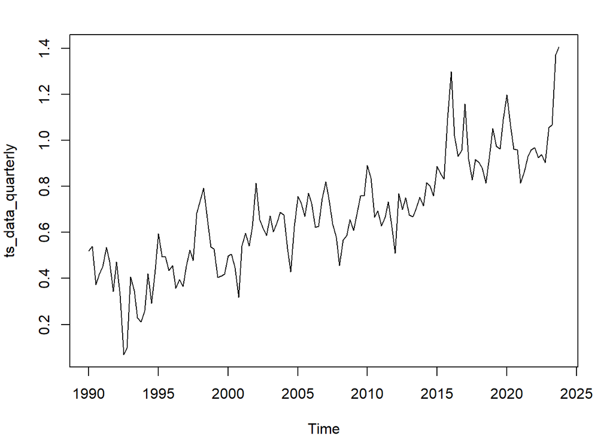

```r
par(mar=c(4,4,2,2)); ts.plot(ts_data_quarterly)
```

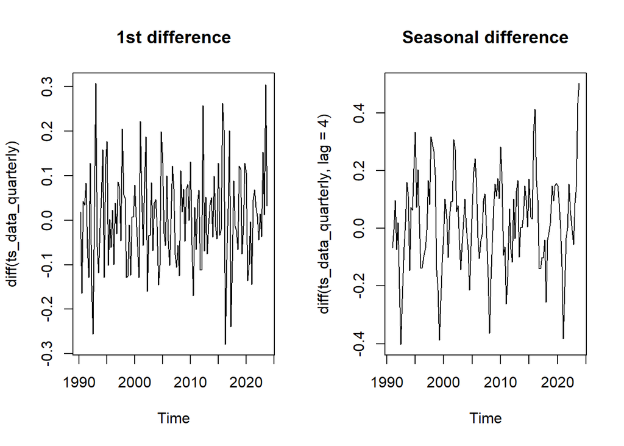

```r
par(mfrow=c(1,2))
plot(diff(ts_data_quarterly), main = '1st difference')
plot(diff(ts_data_quarterly, lag = 4), main = 'Seasonal difference')
```

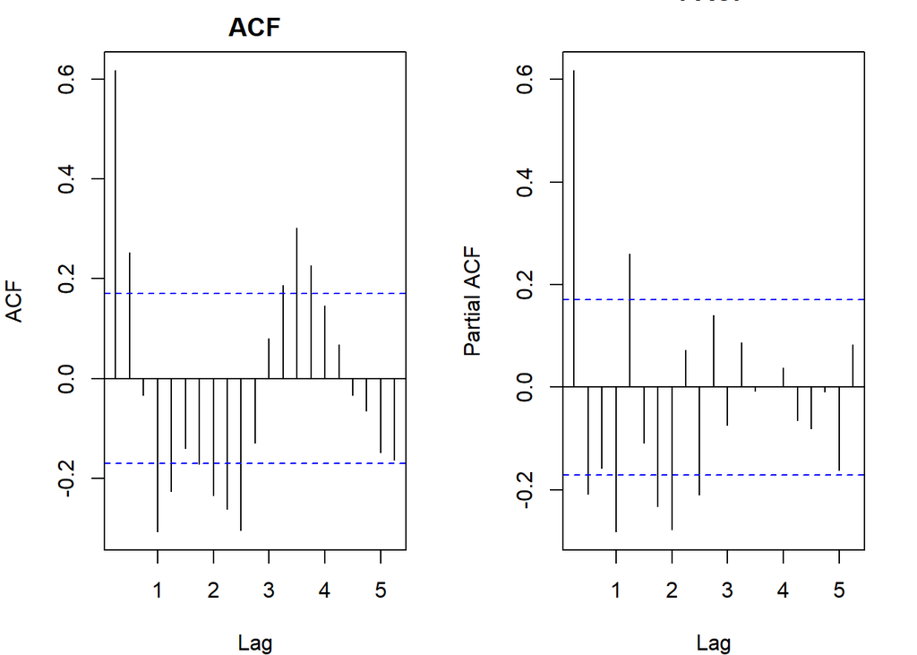

```r
par(mfrow=c(1,2), mar=c(4,4,2,2))
acf(diff(ts_data_quarterly, lag = 4), main = 'ACF')
pacf(diff(ts_data_quarterly, lag = 4), main = 'PACF')
```

```r
mod <- auto.arima(diff(ts_data_quarterly, lag = 4))
mod
```

```
## Series: diff(ts_data_quarterly, lag = 4)
## ARIMA(1,0,1)(0,0,1)[4] with non-zero mean
##
## Coefficients:
##          ar1     ma1     sma1    mean
##       0.5665  0.2063  -0.9114  0.0220
## s.e.  0.1169  0.1336   0.0649  0.0031
##
## sigma^2 = 0.00963:  log likelihood = 117.38
## AIC=-224.76   AICc=-224.28   BIC=-210.35
```

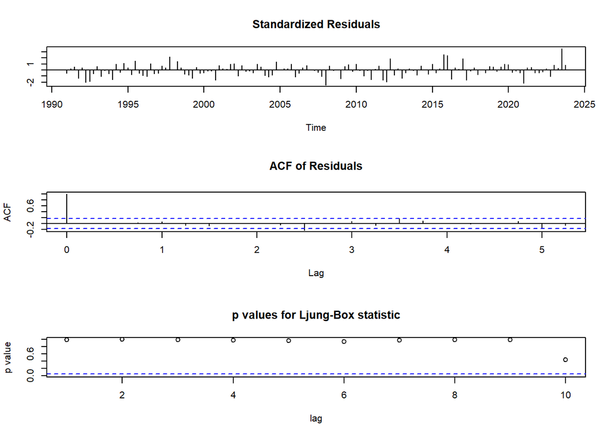

```r
tsdiag(mod)
```

```r
#SARIMA MODEL
mod1 <- auto.arima(ts_data_quarterly, seasonal = TRUE)
mod1
```

```
## Series: ts_data_quarterly
## ARIMA(0,1,0)(1,0,1)[4]
##
## Coefficients:
##         sar1     sma1
##       0.8299  -0.6599
## s.e.  0.2169   0.2975
##
## sigma^2 = 0.01127:  log likelihood = 111.95
## AIC=-217.9   AICc=-217.72   BIC=-209.19
```

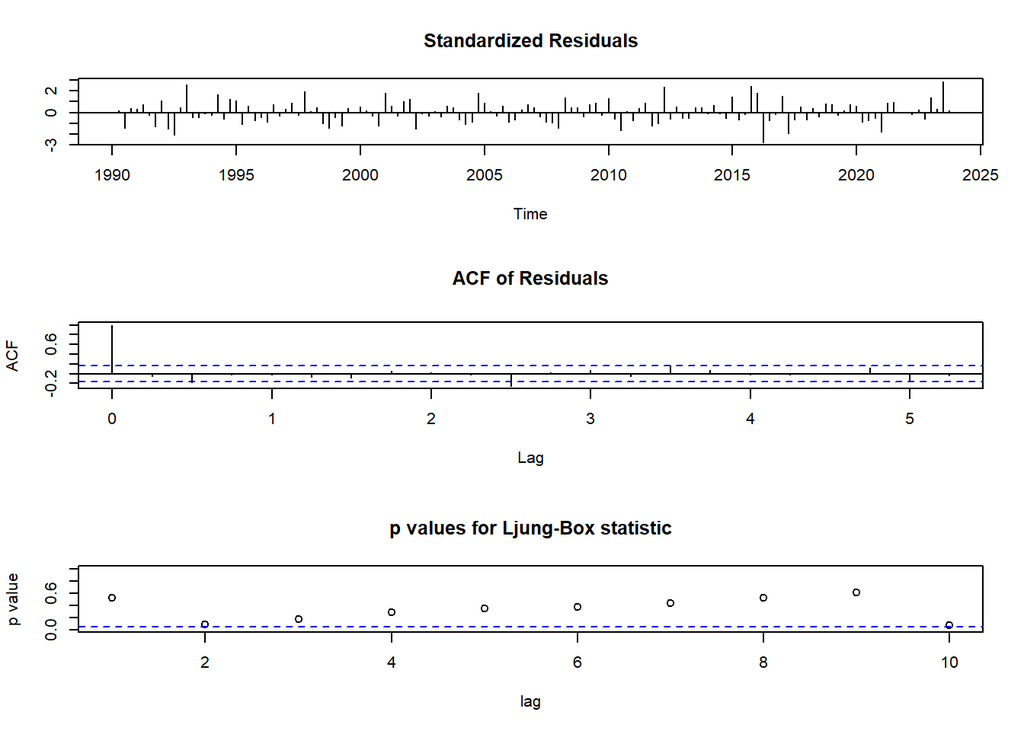

```r
tsdiag(mod1)
```

```r
#ARIMA MODEL
mod2 <- Arima(ts_data_quarterly, order = c(2,1,2), include.drift = TRUE)
mod2
```

```
## Series: ts_data_quarterly
## ARIMA(2,1,2) with drift
##
## Coefficients:
##          ar1     ar2      ma1      ma2   drift
##       0.3403  0.0791  -0.5652  -0.4348  0.0054
## s.e.  0.2686  0.2004   0.2516   0.2507  0.0005
##
## sigma^2 = 0.01004:  log likelihood = 119.69
## AIC=-227.37   AICc=-226.72   BIC=-209.94
```

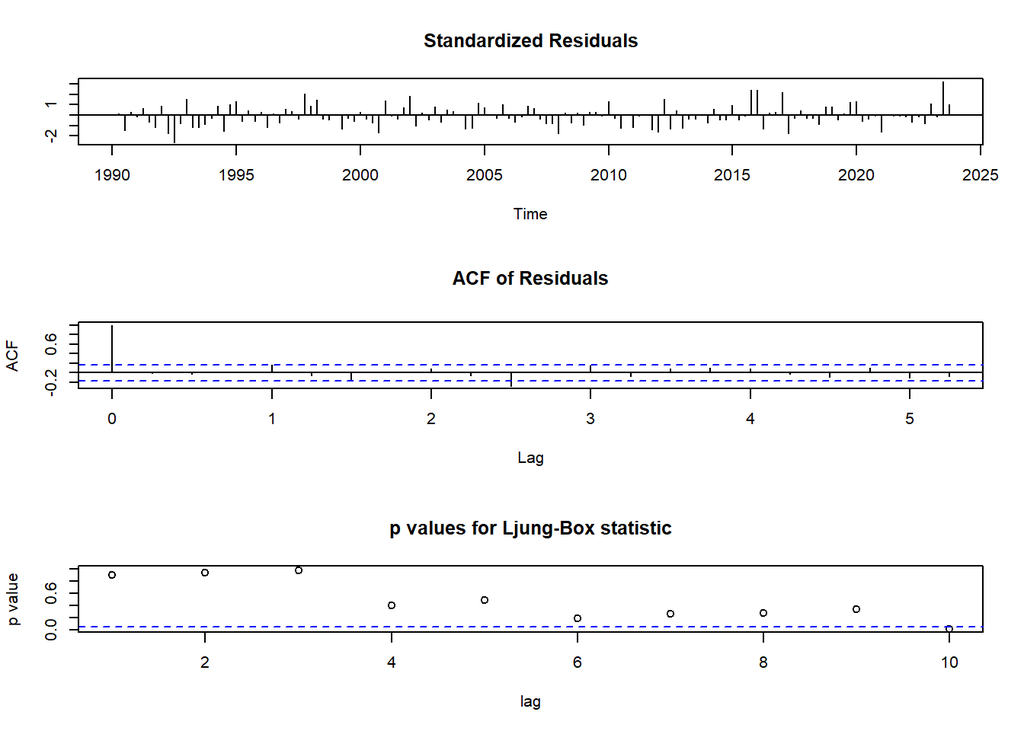

```r
tsdiag(mod2)
```

```r
#ARMA MODEL
mod3 <- Arima(ts_data_quarterly, order = c(2,0,1))
mod3
```

```
## Series: ts_data_quarterly
## ARIMA(2,0,1) with non-zero mean
##
## Coefficients:
##          ar1     ar2     ma1    mean
##       0.3236  0.5334  0.6715  0.7157
## s.e.  0.4234  0.3971  0.3917  0.1018
##
## sigma^2 = 0.01192:  log likelihood = 109.31
## AIC=-208.61   AICc=-208.15   BIC=-194.05
```

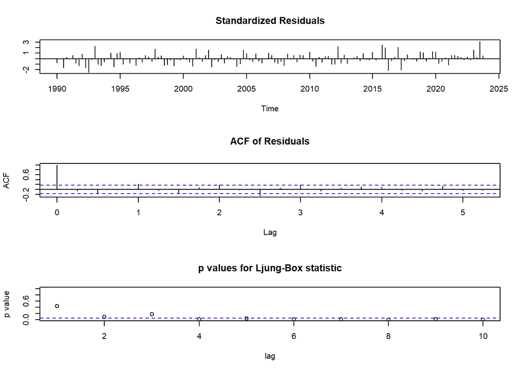

```r
tsdiag(mod3)
```

```r
mod4 <- auto.arima(ts_data_quarterly, max.p = 2, max.q = 2, max.d = 0, seasonal = FALSE)
mod4
```

```
## Series: ts_data_quarterly
## ARIMA(1,0,0) with non-zero mean
##
## Coefficients:
##          ar1    mean
##       0.9208  0.7225
## s.e.  0.0368  0.1097
##
## sigma^2 = 0.01186:  log likelihood = 108.62
## AIC=-211.25   AICc=-211.07   BIC=-202.51
```

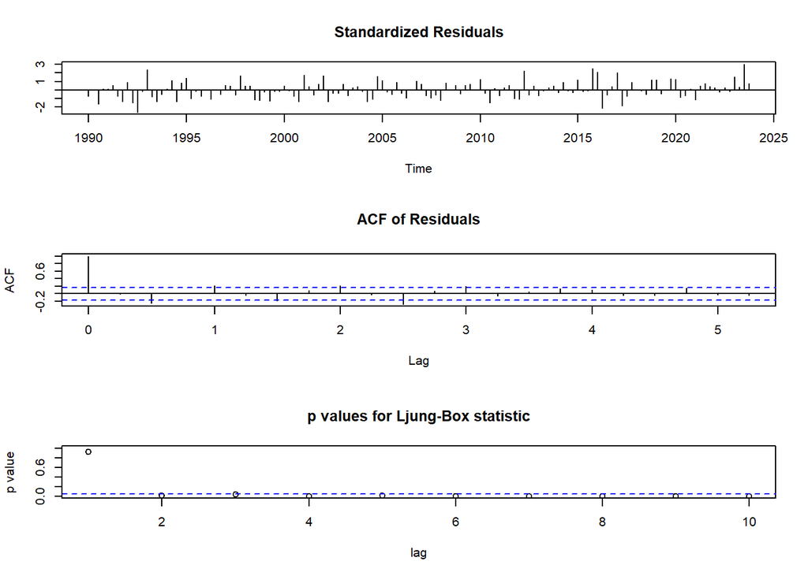

```r
tsdiag(mod4)
```

```r
mod5 <- arima(ts_data_quarterly, order = c(1,1,0),seasonal = list(order= c(1,0,0),period = 12),include.mean = FALSE)
mod5
```

```
##
## Call:
## arima(x = ts_data_quarterly, order = c(1, 1, 0), seasonal = list(order = c(1,
##     0, 0), period = 12), include.mean = FALSE)
##
## Coefficients:
##           ar1    sar1
##       -0.0542  0.2281
## s.e.   0.0857  0.0912
##
## sigma^2 estimated as 0.01144:  log likelihood = 109.88,  aic = -215.75
```

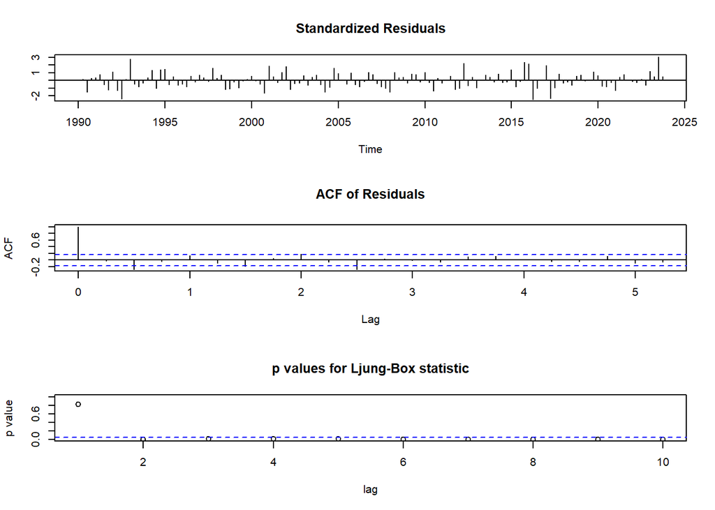

```r
tsdiag(mod5)
```

```r
#SARIMA MODEL
mod6 <- auto.arima(ts_data_quarterly,trace = TRUE)
```

```
##
##  ARIMA(2,1,2)(1,0,1)[4] with drift         : Inf
##  ARIMA(0,1,0)           with drift         : -209.6487
##  ARIMA(1,1,0)(1,0,0)[4] with drift         : -211.1987
##  ARIMA(0,1,1)(0,0,1)[4] with drift         : -210.212
##  ARIMA(0,1,0)                              : -211.2278
##  ARIMA(0,1,0)(1,0,0)[4] with drift         : -213.0615
##  ARIMA(0,1,0)(2,0,0)[4] with drift         : -214.6296
##  ARIMA(0,1,0)(2,0,1)[4] with drift         : -214.2536
##  ARIMA(0,1,0)(1,0,1)[4] with drift         : -215.8307
##  ARIMA(0,1,0)(0,0,1)[4] with drift         : -211.717
##  ARIMA(0,1,0)(1,0,2)[4] with drift         : Inf
##  ARIMA(0,1,0)(0,0,2)[4] with drift         : -212.0862
##  ARIMA(0,1,0)(2,0,2)[4] with drift         : -215.0302
##  ARIMA(1,1,0)(1,0,1)[4] with drift         : -214.0445
##  ARIMA(0,1,1)(1,0,1)[4] with drift         : Inf
##  ARIMA(1,1,1)(1,0,1)[4] with drift         : Inf
##  ARIMA(0,1,0)(1,0,1)[4]                    : -217.7177
##  ARIMA(0,1,0)(0,0,1)[4]                    : -213.3823
##  ARIMA(0,1,0)(1,0,0)[4]                    : -214.7576
##  ARIMA(0,1,0)(2,0,1)[4]                    : -216.1456
##  ARIMA(0,1,0)(1,0,2)[4]                    : Inf
##  ARIMA(0,1,0)(0,0,2)[4]                    : -213.8101
##  ARIMA(0,1,0)(2,0,0)[4]                    : -216.4219
##  ARIMA(0,1,0)(2,0,2)[4]                    : -216.8732
##  ARIMA(1,1,0)(1,0,1)[4]                    : -215.9498
##  ARIMA(0,1,1)(1,0,1)[4]                    : Inf
##  ARIMA(1,1,1)(1,0,1)[4]                    : Inf
##
##  Best model: ARIMA(0,1,0)(1,0,1)[4]
```

```r
mod6
```

```
## Series: ts_data_quarterly
## ARIMA(0,1,0)(1,0,1)[4]
##
## Coefficients:
##         sar1     sma1
##       0.8299  -0.6599
## s.e.  0.2169   0.2975
##
## sigma^2 = 0.01127:  log likelihood = 111.95
## AIC=-217.9   AICc=-217.72   BIC=-209.19
```

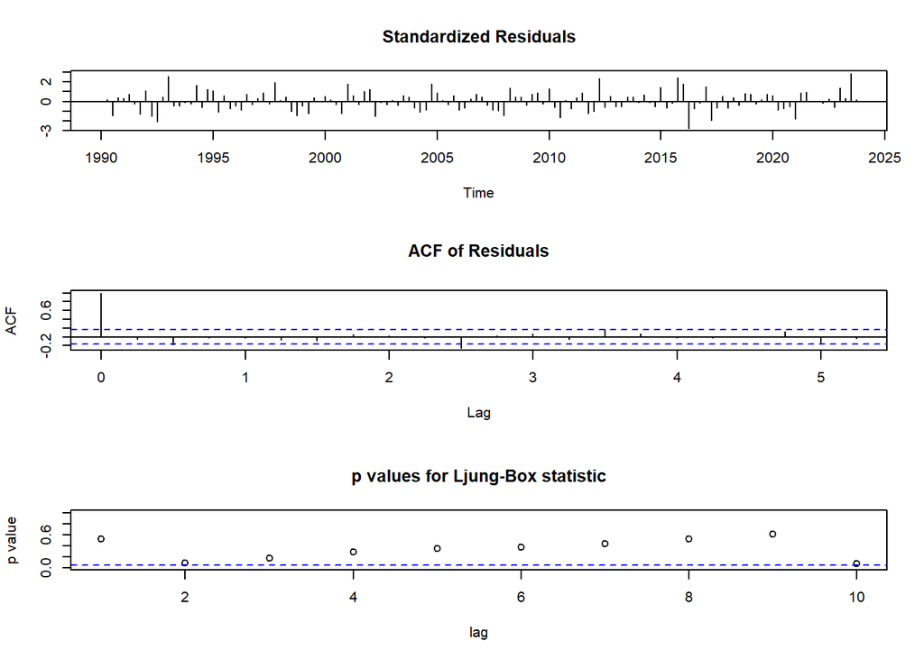

```r
tsdiag(mod6)
```

- Fitting a ARMA, ARIMA and SARIMA models on the quarterly dataset.
- After analyzing the models with different p and q values with maximum p & q values of 2 and maximum d value of 1. Taking number of lags/ seasonal period = 4
- AIC plays a vital role in deciding the best model. However, we cannot rely on only AIC values so we should also consider the residual plots and the S.E values of the model fit.
- after looking at the residual plots and the lowest AIC and BIC values i have assumed the best fit model as ARIMA(0,1,0)(1,0,1)[4] with the AIC =-217.9 and log-likelihood = 111.95 and ARIMA(2,1,2) with log likelihood = 119.69and AIC=-227.37
- We have 2 models one with without seasonal and another is with seasonal for the quarterly data.

# 2)d)

```r
library(dlm)
```

# Quarterly data

```r
buildFun <- function(x) {
dlmModPoly(order = 2, dV = exp(x[1]), dW = c(0, exp(x[2]))) +
dlmModSeas(frequency = 4, dV = 0, dW = c(exp(x[3]), rep(0,2)))
}
```

```r
fit_q <- dlmMLE(ts_data_quarterly, parm = c(0,0,0), build = buildFun)
fit_q$par
```

```
## [1]  -5.217363  -7.041110 -10.923369
```

```r
fitted_model_q <- buildFun(fit_q$par)
V(fitted_model_q)
```

```
##             [,1]
## [1,] 0.005421606
```

```r
W(fitted_model_q)
```

```
##      [,1]         [,2]         [,3] [,4] [,5]
## [1,]    0 0.0000000000 0.000000e+00    0    0
## [2,]    0 0.0008751549 0.000000e+00    0    0
## [3,]    0 0.0000000000 1.803188e-05    0    0
## [4,]    0 0.0000000000 0.000000e+00    0    0
## [5,]    0 0.0000000000 0.000000e+00    0    0
```

```r
fitted_model_q
```

```
## $FF
##      [,1] [,2] [,3] [,4] [,5]
## [1,]    1    0    1    0    0
##
## $V
##             [,1]
## [1,] 0.005421606
##
## $GG
##      [,1] [,2] [,3] [,4] [,5]
## [1,]    1    1    0    0    0
## [2,]    0    1    0    0    0
## [3,]    0    0   -1   -1   -1
## [4,]    0    0    1    0    0
## [5,]    0    0    0    1    0
##
## $W
##      [,1]         [,2]         [,3] [,4] [,5]
## [1,]    0 0.0000000000 0.000000e+00    0    0
## [2,]    0 0.0008751549 0.000000e+00    0    0
## [3,]    0 0.0000000000 1.803188e-05    0    0
## [4,]    0 0.0000000000 0.000000e+00    0    0
## [5,]    0 0.0000000000 0.000000e+00    0    0
##
## $m0
## [1] 0 0 0 0 0
##
## $C0
##       [,1]  [,2]  [,3]  [,4]  [,5]
## [1,] 1e+07 0e+00 0e+00 0e+00 0e+00
## [2,] 0e+00 1e+07 0e+00 0e+00 0e+00
## [3,] 0e+00 0e+00 1e+07 0e+00 0e+00
## [4,] 0e+00 0e+00 0e+00 1e+07 0e+00
## [5,] 0e+00 0e+00 0e+00 0e+00 1e+07
```

# Monthly data

```r
buildFun_m <- function(x) {
dlmModPoly(order = 2, dV = exp(x[1]), dW = c(0, exp(x[2]))) +
dlmModSeas(frequency = 4, dV = 0, dW = c(exp(x[3]), rep(0,2)))
}
```

```r
fit_m <- dlmMLE(ts_data, parm = c(0,0,0), build = buildFun_m)
fit_m$par
```

```
## [1] -2.104770 -2.758302 -3.600238
```

```r
fitted_model_m <- buildFun(fit_m$par)
V(fitted_model_m)
```

```
##           [,1]
## [1,] 0.1218738
```

```r
W(fitted_model_m)
```

```
##      [,1]       [,2]       [,3] [,4] [,5]
## [1,]    0 0.00000000 0.00000000    0    0
## [2,]    0 0.06339931 0.00000000    0    0
## [3,]    0 0.00000000 0.02731722    0    0
## [4,]    0 0.00000000 0.00000000    0    0
## [5,]    0 0.00000000 0.00000000    0    0
```

# 2)e)

# Forecasting quaterly data

```r
anom_quaterly <- dlmFilter(ts_data_quarterly, mod = fitted_model_q)
summary(anom_quaterly)
```

```
##     Length Class  Mode
## y   136    ts     numeric
## mod  10    dlm    list
## m   685    mts    numeric
## U.C 137    -none- list
## D.C 685    -none- numeric
## a   680    mts    numeric
## U.R 136    -none- list
## D.R 680    -none- numeric
## f   136    ts     numeric
```

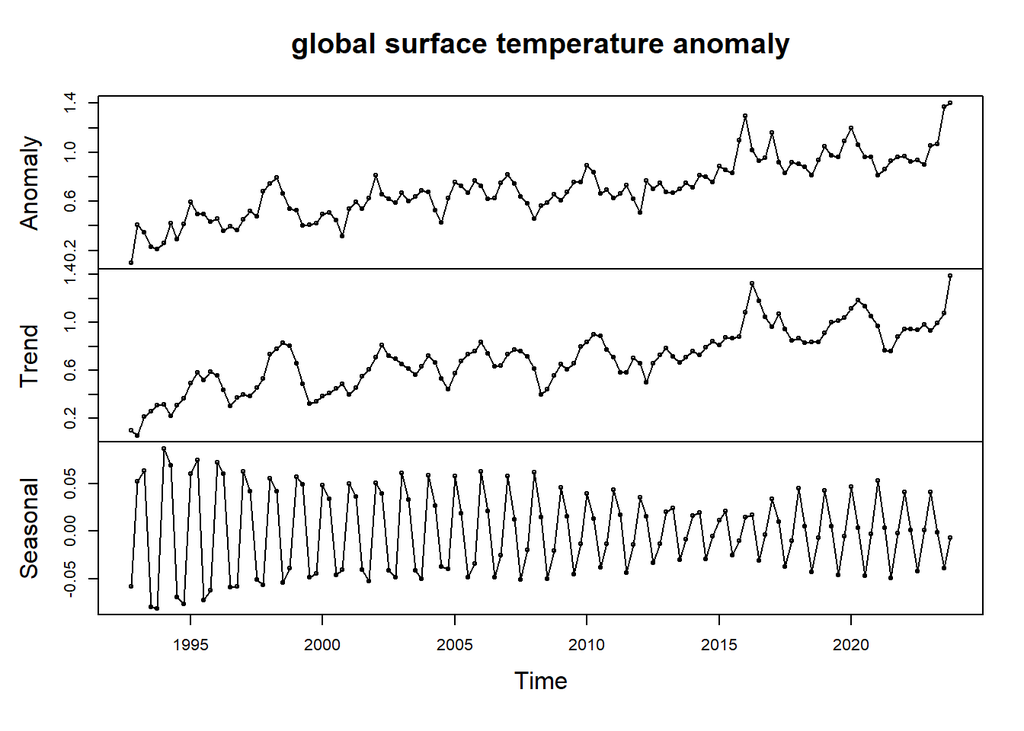

```r
x <- cbind(ts_data_quarterly, dropFirst(anom_quaterly$a[,c(1,3)]))
x <- window(x, start = c(1990,12))
colnames(x) <- c("Anomaly", "Trend", "Seasonal")
plot(x, type = 'o', main = "global surface temperature anomaly")
```

```r
AnomFore <- dlmForecast(anom_quaterly, nAhead = 12)
summary(AnomFore)
```

```
##   Length Class  Mode
## a 60     mts    numeric
## R 12     -none- list
## f 12     ts     numeric
## Q 12     -none- list
```

```r
dim(AnomFore$a)
```

```
## [1] 12  5
```

```r
dim(AnomFore$f)
```

```
## [1] 12  1
```

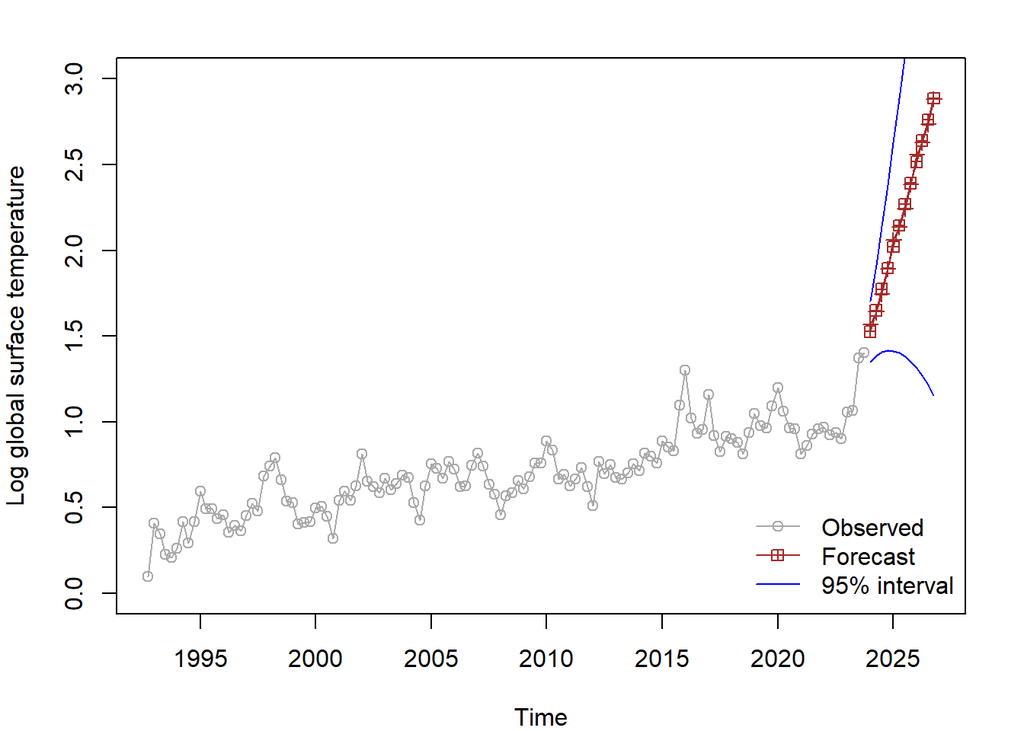

```r
sqrtR <- sapply(AnomFore$R, function(x) sqrt(x[1,1]))
pl <- AnomFore$a[,1] + qnorm(0.025, sd = sqrtR)
pu <- AnomFore$a[,1] + qnorm(0.975, sd = sqrtR)
x <- ts.union(window(ts_data_quarterly, start = c(1990, 12)),
AnomFore$a[,1],
AnomFore$f, pl, pu)
par(mar=c(4,4,2,2))
plot(x, plot.type = "single", type = 'o', pch = c(1, 12, 3, NA, NA),
col = c("darkgrey", "brown", "brown", "blue", "blue"),
ylab = "Log global surface temperature",ylim = c(0.001, 3))
legend("bottomright", legend = c("Observed",
"Forecast", "95% interval"),
bty = 'n', pch = c(1, 12, NA), lty = 1,
col = c("darkgrey", "brown", "blue"))
```

- The forecast of the quarterly data by dlm model shows the increasing trend in the year 2024.However, the 95% confidence interval values are not plotted correct which tells that data has some uncertainty.

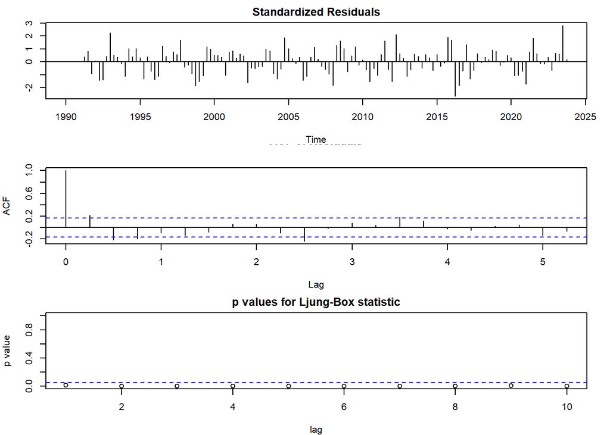

```r
par(mar=c(4,4,2,2));tsdiag(anom_quaterly)
```

# Forecasting monthly data

```r
anom_monthly <- dlmFilter(ts_data, mod = fitted_model_m)
summary(anom_monthly)
```

```
##     Length Class  Mode
## y    408   ts     numeric
## mod   10   dlm    list
## m   2045   mts    numeric
## U.C  409   -none- list
## D.C 2045   -none- numeric
## a   2040   mts    numeric
## U.R  408   -none- list
## D.R 2040   -none- numeric
## f    408   ts     numeric
```

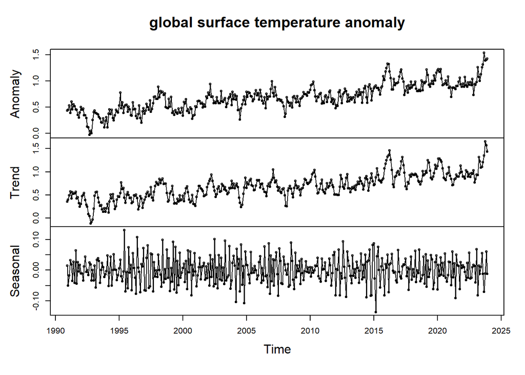

```r
x <- cbind(ts_data, dropFirst(anom_monthly$a[,c(1,3)]))
x <- window(x, start = c(1990,12))
colnames(x) <- c("Anomaly", "Trend", "Seasonal")
plot(x, type = 'o', main = "global surface temperature anomaly")
```

```r
AnomFore_m <- dlmForecast(anom_monthly, nAhead = 12)
summary(AnomFore_m)
```

```
##   Length Class  Mode
## a 60     mts    numeric
## R 12     -none- list
## f 12     ts     numeric
## Q 12     -none- list
```

```r
dim(AnomFore_m$a)
```

```
## [1] 12  5
```

```r
dim(AnomFore_m$f)
```

```
## [1] 12  1
```

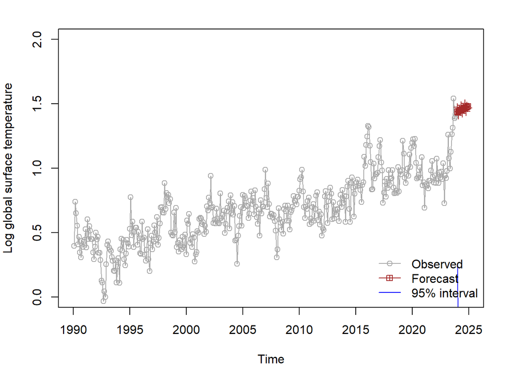

```r
sqrtR <- sapply(AnomFore_m$R, function(x) sqrt(x[1,1]))
pl <- AnomFore_m$a[,1] + qnorm(0.025, sd = sqrtR)
pu <- AnomFore_m$a[,1] + qnorm(0.975, sd = sqrtR)
x <- ts.union(window(ts_data, start = c(1990, 2)),
AnomFore_m$a[,1],
AnomFore_m$f, pl, pu)
par(mar=c(4,4,2,2))
plot(x, plot.type = "single", type = 'o', pch = c(1, 12, 3, NA, NA),
col = c("darkgrey", "brown", "brown", "blue", "blue"),
ylab = "Log global surface temperature",ylim = c(0.0001, 2))
legend("bottomright", legend = c("Observed",
"Forecast", "95% interval"),
bty = 'n', pch = c(1, 12, NA), lty = 1,
col = c("darkgrey", "brown", "blue"))
```

- The forecast of the monthly data by dlm model shows a slight increasing trend in the year 2024.

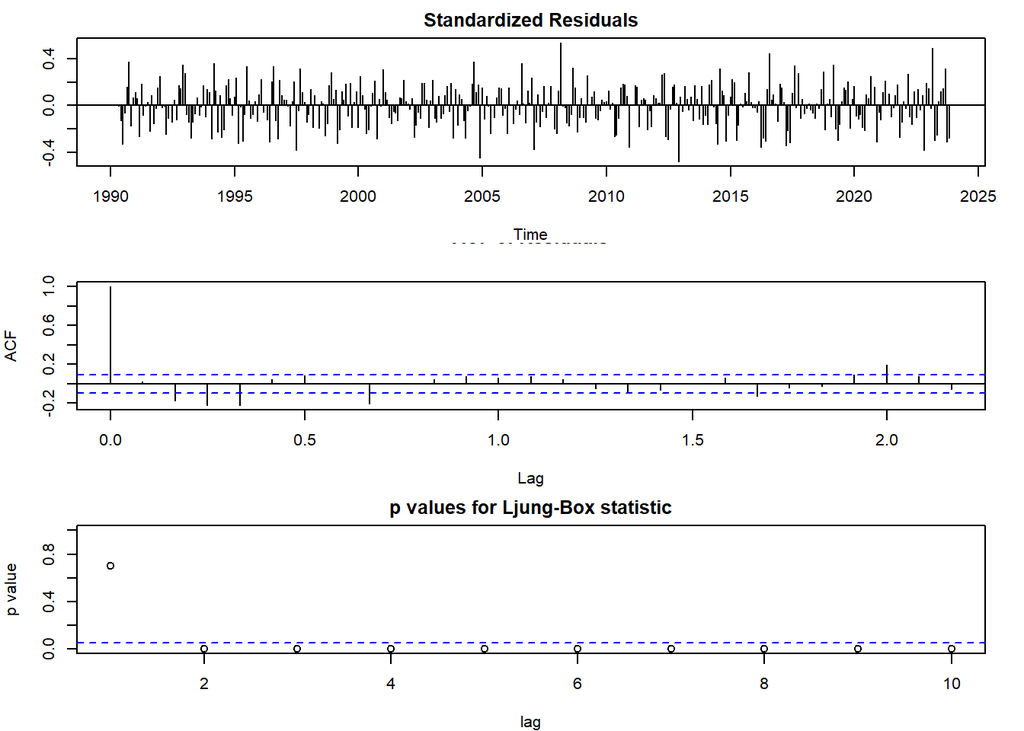

```r
par(mar=c(4,4,2,2));tsdiag(anom_monthly)
```

# Forecasting of best ARIMA model of c)

```r
forecast1 = forecast(mod2, 4)
forecast1
```

```
##         Point Forecast     Lo 80    Hi 80     Lo 95    Hi 95
## 2024 Q1       1.245672 1.1167840 1.374560 1.0485548 1.442789
## 2024 Q2       1.153952 0.9903188 1.317585 0.9036966 1.404208
## 2024 Q3       1.113333 0.9434104 1.283256 0.8534588 1.373207
## 2024 Q4       1.095399 0.9236729 1.267126 0.8327664 1.358032
```

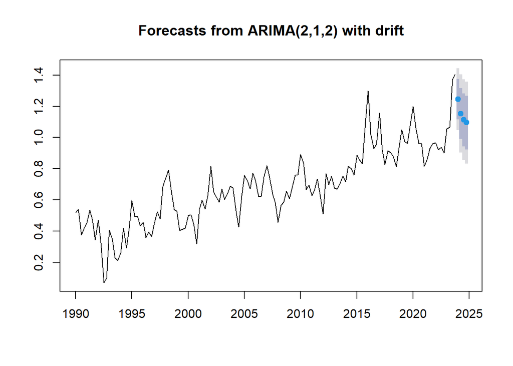

```r
plot(forecast1)
```

- The forecast of the data by ARIMA model taking difference shows the decreasing trend in the year 2024.

```r
forecast2 = forecast(mod6, 4)
forecast2
```

```
##         Point Forecast    Lo 80    Hi 80    Lo 95    Hi 95
## 2024 Q1       1.434368 1.298344 1.570392 1.226337 1.642399
## 2024 Q2       1.420077 1.227710 1.612444 1.125877 1.714277
## 2024 Q3       1.469561 1.233960 1.705162 1.109241 1.829881
## 2024 Q4       1.482716 1.210668 1.754765 1.066654 1.898778
```

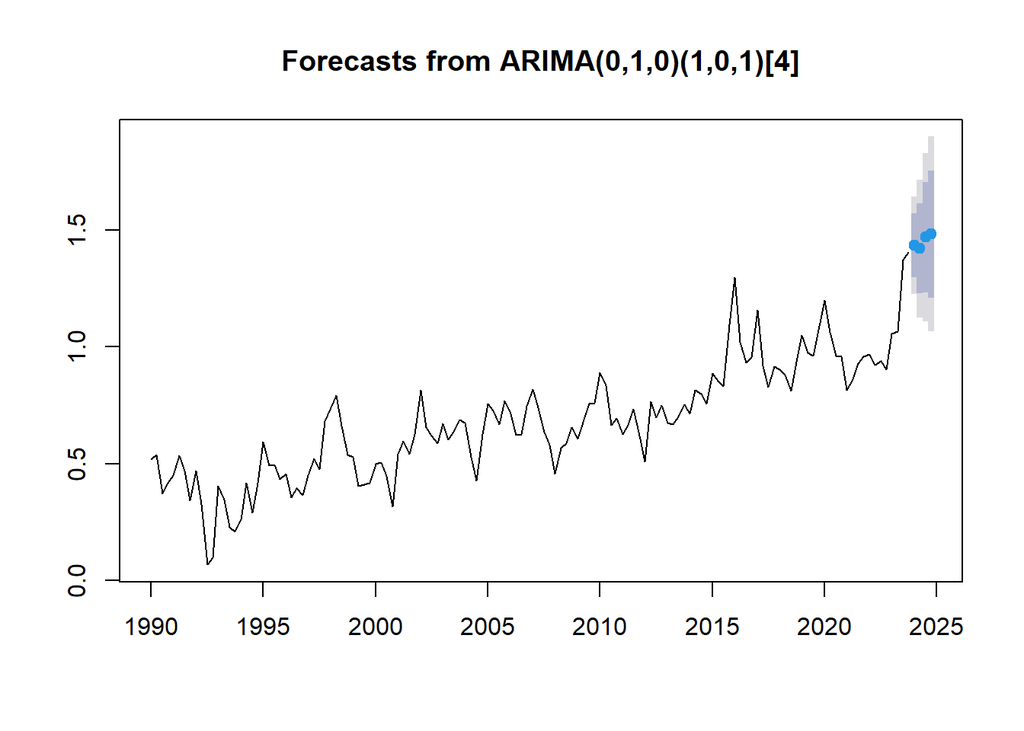

```r
plot(forecast2)
```

- The forecast of the data by SARIMA model with the seasonal term we can observe that there are fluctuations in the year 2024 of model prediction but overall we can see a positive trend in the model.

# Forecasting of best ARIMA model of b)

```r
forecast3 = forecast(model_arima4, 12)
forecast3
```

```
##          Point Forecast     Lo 80    Hi 80     Lo 95    Hi 95
## Jan 2024       1.336348 1.1970140 1.475683 1.1232549 1.549442
## Feb 2024       1.267248 1.1059839 1.428512 1.0206158 1.513880
## Mar 2024       1.217967 1.0383128 1.397622 0.9432094 1.492726
## Apr 2024       1.179737 0.9941852 1.365289 0.8959599 1.463515
## May 2024       1.152694 0.9617114 1.343677 0.8606111 1.444778
## Jun 2024       1.131897 0.9390507 1.324744 0.8369639 1.426830
## Jul 2024       1.117415 0.9228176 1.312012 0.8198042 1.415025
## Aug 2024       1.106462 0.9112393 1.301685 0.8078946 1.405029
## Sep 2024       1.099074 0.9032599 1.294887 0.7996023 1.398545
## Oct 2024       1.093680 0.8976456 1.289715 0.7938710 1.393490
## Nov 2024       1.090299 0.8940549 1.286543 0.7901695 1.390429
## Dec 2024       1.088045 0.8917181 1.284373 0.7877887 1.388302
```

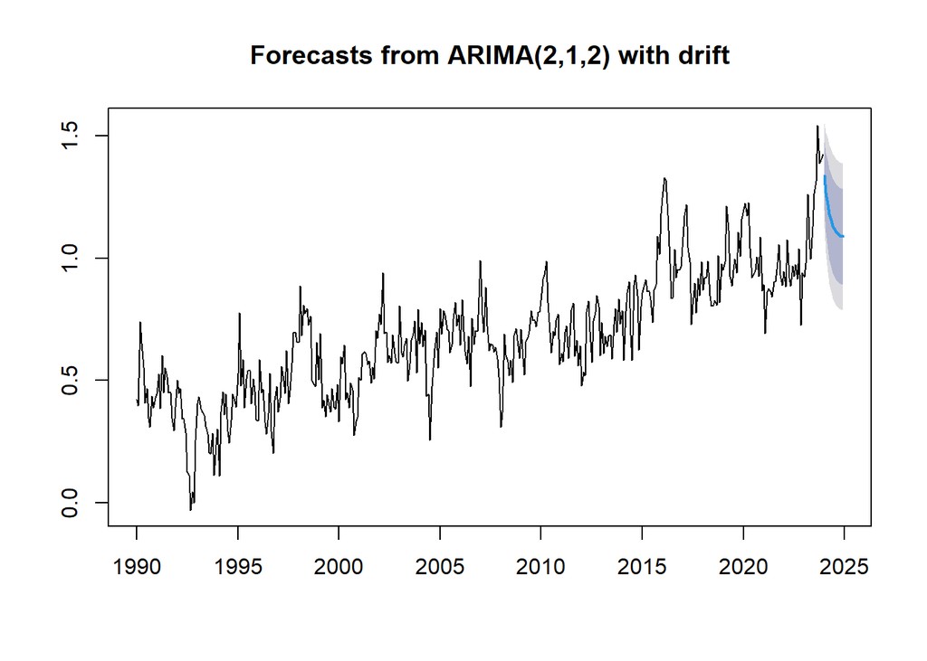

```r
plot(forecast3)
```

- The forecast of the data by ARIMA(2,1,2) model taking difference shows the decreasing trend in the year 2024.

# 3)a)

```r
library(dplyr)
library(tidyr)
library(lubridate)
library(sp)
library(gstat)
library(fields)
uk_loc <- read.csv("D:/ADIL/Downloads/data/uk_loc.csv")
```

```r
uk_temp <- read.csv("D:/ADIL/Downloads/data/uk_temp.csv",stringsAsFactors = FALSE)
```

```r
# Convert uk_temp to long format and merge with uk_loc
new_uk_temp <- pivot_longer(uk_temp, cols = -Date, names_to = "station_name", values_to = "max_temp")
new_uk_temp$Date <- as.Date(new_uk_temp$Date, format = "%Y-%m-%d")
```

```r
uk_data <- merge(uk_loc,new_uk_temp,by='station_name')
```

```r
library(ggplot2)
```

# a. Spatial and time series plots

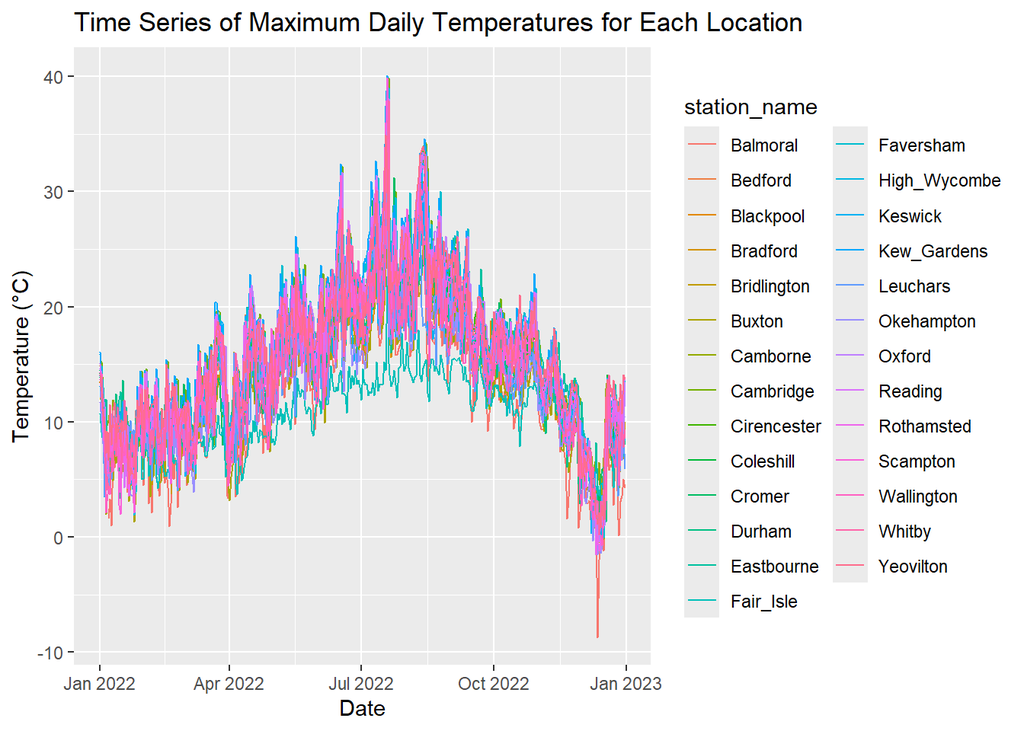

```r
# Time series plot for each location
ggplot(uk_data, aes(x = Date, y = max_temp, group = station_name, color = station_name)) +
  geom_line() +
  labs(title = "Time Series of Maximum Daily Temperatures for Each Location", x = "Date", y = "Temperature (°C)") +
  theme(legend.position = "right")
```

This plot shows the maximum daily temperatures for different locations in the UK throughout the year 2022 in a time series format.

- Seasonal trends can be observed in the plot, with temperatures reaching their peak during the summer months (around July and August 2022) and dropping to lower values in the winter months. While the seasonal pattern is consistent across all locations, there are noticeable differences in temperature ranges and peak values.
- Each location exhibits significant day-to-day variability in maximum temperatures, with some days experiencing much higher or lower temperatures than the surrounding days. The plot highlights potential extreme temperature events such as heatwaves or cold snaps, where maximum temperatures for multiple locations spike or dip significantly compared to the typical range. These events could have implications for sectors like agriculture, energy demand, or public health.

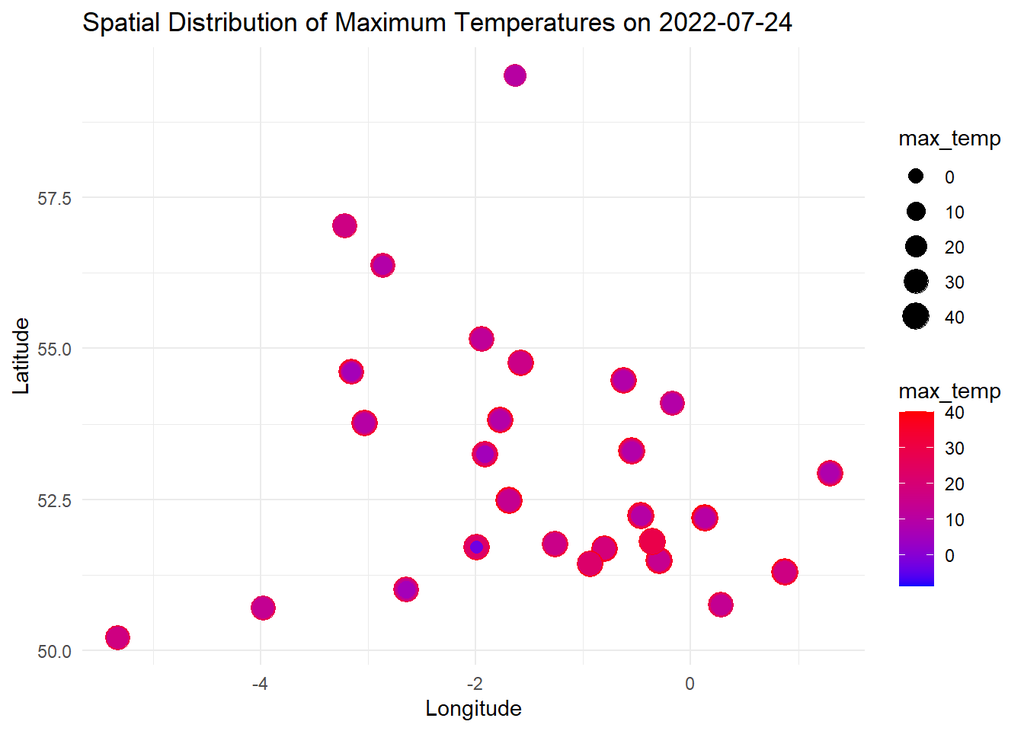

```r
# Spatial plot
ggplot(uk_data, aes(x = station_longitude, y = station_latitude, color = max_temp)) +
  geom_point(aes(size = max_temp)) +
  labs(title = "Spatial Distribution of Maximum Temperatures on 2022-07-24", x = "Longitude", y = "Latitude") +
  scale_color_gradient(low = "blue", high = "red") +
  theme_minimal()
```

```r
str(uk_data)
```

```
## 'data.frame':    9855 obs. of  6 variables:
##  $ station_name     : chr  "Balmoral" "Balmoral" "Balmoral" "Balmoral" ...
##  $ station_longitude: num  -3.22 -3.22 -3.22 -3.22 -3.22 -3.22 -3.22 -3.22 -3.22 -3.22 ...
##  $ station_latitude : num  57 57 57 57 57 ...
##  $ station_elevation: int  283 283 283 283 283 283 283 283 283 283 ...
##  $ Date             : Date, format: "2022-01-01" "2022-09-01" ...
##  $ max_temp         : num  NA 19.8 1.6 3 13.3 13.1 29.3 5.9 7.8 9.3 ...
```

# 3)b)

```r
july24_data <- new_uk_temp %>% filter(Date == "2022-07-24") %>% left_join(uk_loc, by = c("station_name" = "station_name"))
```

```r
geo_data <- as.geodata(july24_data, coords.col = 4:5, data.col = 6)
```

```r
gp_mod <- likfit(geo_data, cov.model = "spherical", ini.cov.pars = c(900, 1.5))
```

```
## kappa not used for the spherical correlation function
## ---------------------------------------------------------------
## likfit: likelihood maximisation using the function optim.
## likfit: Use control() to pass additional
##          arguments for the maximisation function.
##         For further details see documentation for optim.
## likfit: It is highly advisable to run this function several
##         times with different initial values for the parameters.
## likfit: WARNING: This step can be time demanding!
## ---------------------------------------------------------------
## likfit: end of numerical maximisation.
```

```r
gp_mod
```

```
## likfit: estimated model parameters:
##     beta    tausq  sigmasq      phi
## "  98.3" "9566.2" "   0.0" "   0.0"
## Practical Range with cor=0.05 for asymptotic range: 0
##
## likfit: maximised log-likelihood = -162.1
```

```r
xv.m1 <- xvalid(geo_data, model = gp_mod)
```

```
## xvalid: number of data locations       = 27
## xvalid: number of validation locations = 27
## xvalid: performing cross-validation at location ... 1, 2, 3, 4, 5, 6, 7, 8, 9, 10, 11, 12, 13, 14, 15, 16, 17, 18, 19, 20, 21, 22, 23, 24, 25, 26, 27,
## xvalid: end of cross-validation
```

```r
par(mfrow=c(3,2),mar=c(4,2,2,2))
plot(xv.m1, error = TRUE, std.error = FALSE, pch = 19)
```

[output not shown]

```r
gp_mod1 <- likfit(geo_data, cov.model = "gaussian", ini.cov.pars = c(900, 1.5))
```

```
## kappa not used for the gaussian correlation function
## ---------------------------------------------------------------
## likfit: likelihood maximisation using the function optim.
## likfit: Use control() to pass additional
##          arguments for the maximisation function.
##         For further details see documentation for optim.
## likfit: It is highly advisable to run this function several
##         times with different initial values for the parameters.
## likfit: WARNING: This step can be time demanding!
## ---------------------------------------------------------------
## likfit: end of numerical maximisation.
```

```r
gp_mod1
```

```
## likfit: estimated model parameters:
##     beta    tausq  sigmasq      phi
## "  98.3" "9566.2" "   0.0" "   0.0"
## Practical Range with cor=0.05 for asymptotic range: 0.0001159668
##
## likfit: maximised log-likelihood = -162.1
```

```r
xv.m2 <- xvalid(geo_data, model = gp_mod1)
```

```
## xvalid: number of data locations       = 27
## xvalid: number of validation locations = 27
## xvalid: performing cross-validation at location ... 1, 2, 3, 4, 5, 6, 7, 8, 9, 10, 11, 12, 13, 14, 15, 16, 17, 18, 19, 20, 21, 22, 23, 24, 25, 26, 27,
## xvalid: end of cross-validation
```

```r
par(mfrow=c(3,2),mar=c(4,2,2,2))
plot(xv.m2, error = TRUE, std.error = FALSE, pch = 19)
```

[output not shown]

```r
gp_model <- likfit(geo_data, cov.model = "matern", ini.cov.pars = c(900, 1.5), kappa = 3/2)
```

```
## ---------------------------------------------------------------
## likfit: likelihood maximisation using the function optim.
## likfit: Use control() to pass additional
##          arguments for the maximisation function.
##         For further details see documentation for optim.
## likfit: It is highly advisable to run this function several
##         times with different initial values for the parameters.
## likfit: WARNING: This step can be time demanding!
## ---------------------------------------------------------------
## likfit: end of numerical maximisation.
```

```r
gp_model
```

```
## likfit: estimated model parameters:
##     beta    tausq  sigmasq      phi
## "  98.3" "9566.2" "   0.0" "   0.0"
## Practical Range with cor=0.05 for asymptotic range: 0.0001159668
##
## likfit: maximised log-likelihood = -162.1
```

```r
xv.ml <- xvalid(geo_data, model = gp_model)
```

```
## xvalid: number of data locations       = 27
## xvalid: number of validation locations = 27
## xvalid: performing cross-validation at location ... 1, 2, 3, 4, 5, 6, 7, 8, 9, 10, 11, 12, 13, 14, 15, 16, 17, 18, 19, 20, 21, 22, 23, 24, 25, 26, 27,
## xvalid: end of cross-validation
```

```r
par(mfrow=c(3,2),mar=c(4,2,2,2))
plot(xv.ml, error = TRUE, std.error = FALSE, pch = 19)
```

[output not shown]

```r
target_locs <- uk_loc %>% filter(station_name %in% c("Wallington", "Reading", "Whitby"))
```

```r
predictions <- krige.conv(geo_data, loc = target_locs[, c("station_longitude", "station_latitude")], krige=krige.control(obj.model=gp_model))
```

```
## krige.conv: model with constant mean
## krige.conv: Kriging performed using global neighbourhood
```

```r
predictions
```

```
## $predict
## [1]  66  41 150
##
## $krige.var
## [1] 0 0 0
##
## $beta.est
##    beta
## 98.2963
##
## $distribution
## [1] "normal"
##
## $message
## [1] "krige.conv: Kriging performed using global neighbourhood"
##
## $call
## krige.conv(geodata = geo_data, locations = target_locs[, c("station_longitude",
##     "station_latitude")], krige = krige.control(obj.model = gp_model))
##
## attr(,"sp.dim")
## [1] "2d"
## attr(,"prediction.locations")
## target_locs[, c("station_longitude", "station_latitude")]
## attr(,"parent.env")
## <environment: R_GlobalEnv>
## attr(,"data.locations")
## geo_data$coords
## attr(,"class")
## [1] "kriging"
```

# 3)c)

```r
# For plotting mean and variance over a grid, we'll create a prediction grid
pred_grid <- expand.grid(seq(min(uk_data$station_longitude), max(uk_data$station_longitude), by =0.05), seq(min(uk_data$station_latitude), max(uk_data$station_latitude), by = 0.05))
```

```r
# Convert grid data to geodata format for prediction
grid_geodata <- as.geodata(pred_grid, coords.col = 1:2, data.col = 2)
```

***below codes runs slow and it takes long time.**

```r
# Predict over the grid
#grid_predictions <- krige.conv(grid_geodata, loc = grid_geodata$coords, krige=krige.control(obj.model=gp_model))
```

```r
#grid_predictions
```

```r
# Convert predictions to a data frame for plotting
#grid_predictions_df <- as.data.frame(grid_predictions)
#colnames(grid_predictions_df) <- c("longitude", "latitude", "predicted_mean", "predicted_variance")
```

```r
# Plotting
#ggplot(grid_predictions_df, aes(x = longitude, y = latitude)) + geom_tile(aes(fill = predicted_mean)) + geom_point(data = uk_loc, aes(x = longitude, y = latitude, color = "red")) + labs(title = "Predicted Mean Temperatures", x = "Longitude", y = "Latitude", fill = "Temperature (°C)")
```

```r
#ggplot(grid_predictions_df, aes(x = longitude, y = latitude)) + geom_tile(aes(fill = predicted_variance)) + geom_point(data = uk_loc, aes(x = longitude, y = latitude, color = "red")) + labs(title = "Variance of Predicted Temperatures", x = "Longitude", y = "Latitude", fill = "Variance")
```